# Monitoramento Funil Blend4

## Execução

```
Última execução: 06/10/2026 10:01:51 -03
```

## Diretório e Configurações

## Base: Blend4 em Produção

```
Volume total (simulação): 428,443
Contratos únicos: 428,443
Período: 2026-07-01 00:00:00 → 2026-10-05 00:00:00
```

```
bureau_nm_ajust
BLEND3                  213892
BLEND4                  213144
BLEND_REGRESSAO_2026      1278
NaN                        129
dtype: int64
```

## Diário e Semanal

```
Diário simulação: 2026-09-28 00:00:00 → 2026-10-05 00:00:00 | n=40,468
```

```
Semanal simulação: 2026-08-30 00:00:00 → 2026-10-05 00:00:00 | n=155,241
```

## Multiproponente vs. Uniproponente

Proporção de Multipronentes vs. Uniproponentes ao longo das semanas. O esperado é algo entre 3-4%.

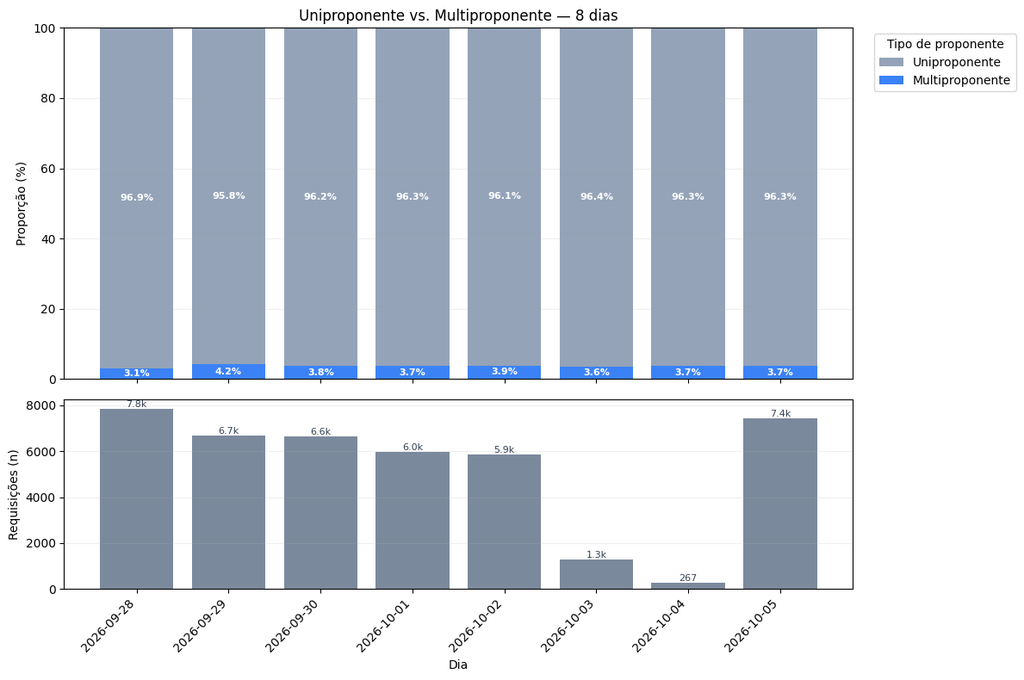

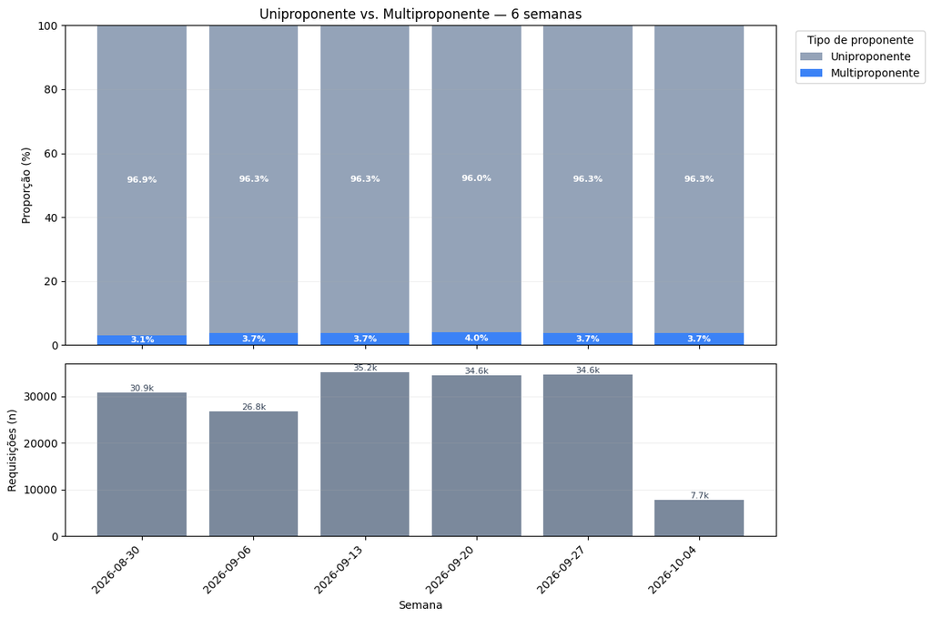

# Uniproponentes

A partir daqui, seguimos apenas com o público Uniproponente.

## Mix de Modelos Diário e Semanal

Mix de Modelos dividido entre Blend3, Blend4 e Fallback. Blend2 foi descontinuado e deu lugar ao Blend4.

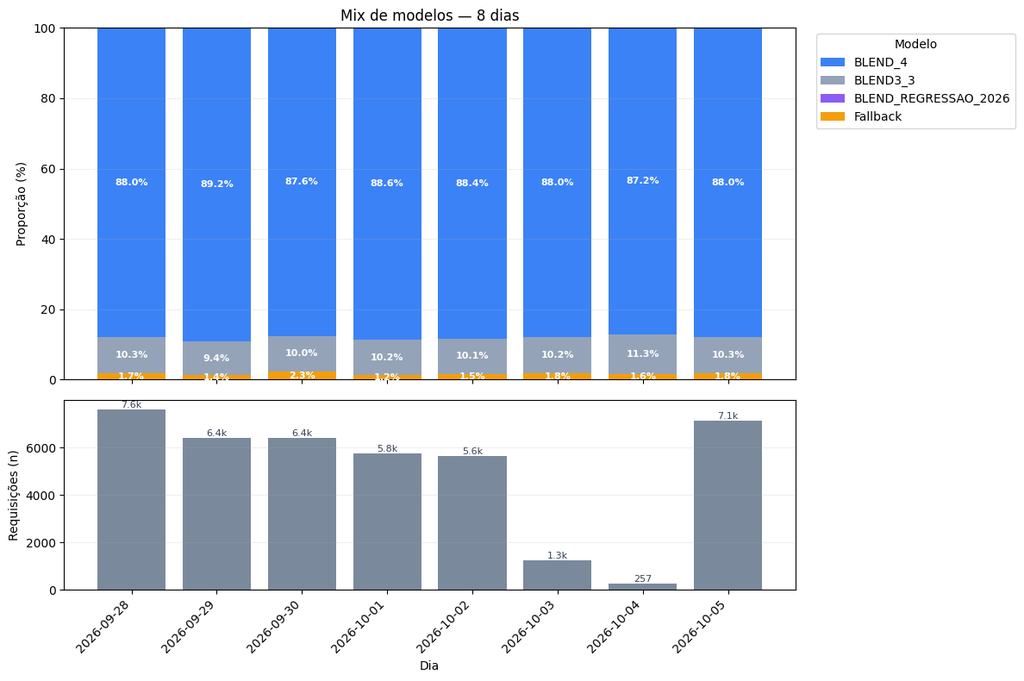

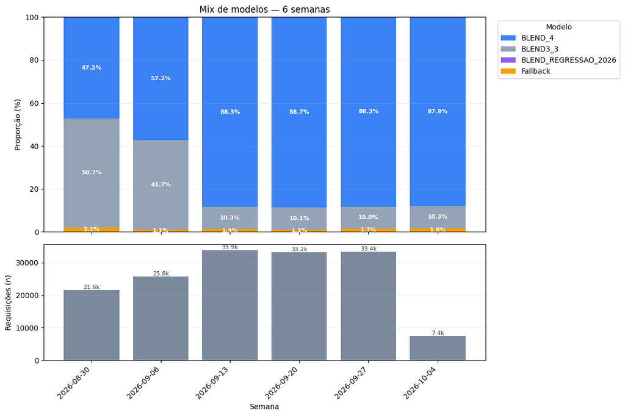

## Mix de Modelos Diário e Semanal

Nesta etapa, retiramos o público que é FALLBACK e seguimos apenas com as comparações entre os Blend's que estão em produção (Blend 3 Blend4).

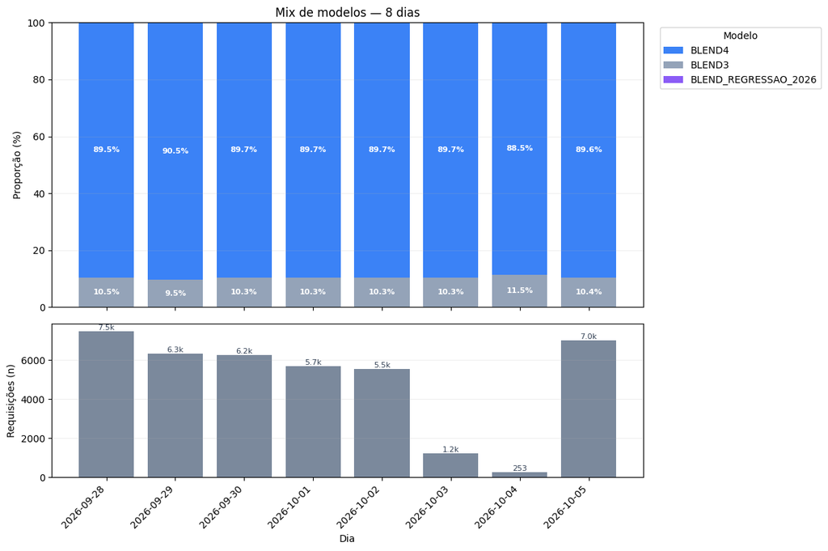

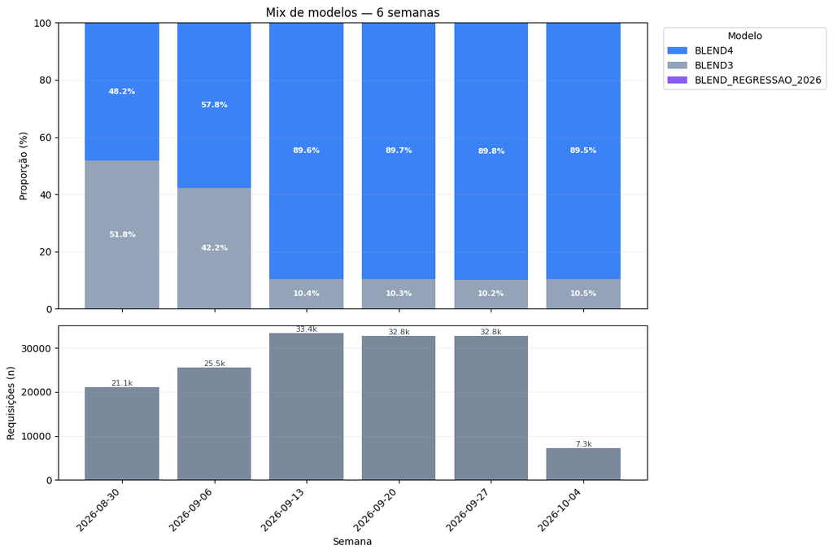

## Pré-Análise

Comparação do percentual de Aprovados, Derivados e Reprovados do Blend3 e Blend4.

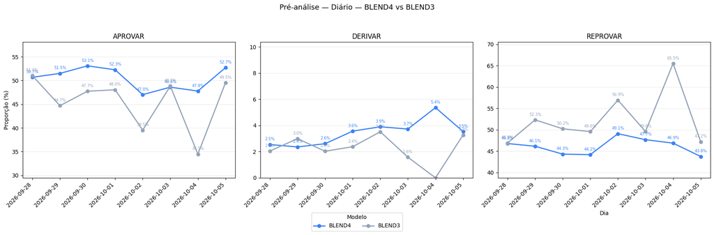

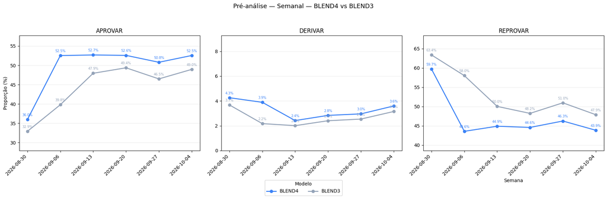

## Pré-Análise sem o Público Rating E do Blend3

Nesse caso, tiramos a elegibilidade do público que é Rating E do Blend 3.

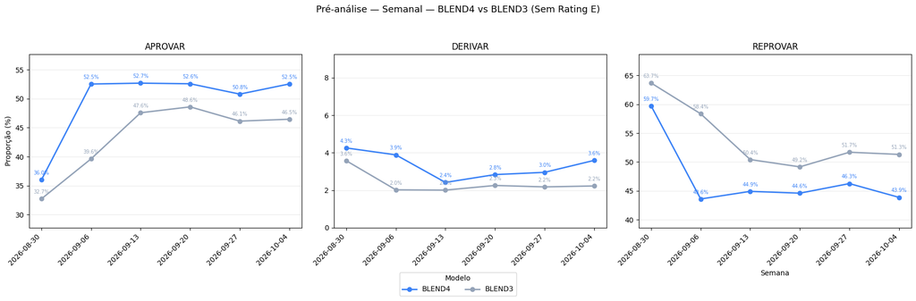

## Funil

Comparação entre Blend3 e Blend4 em relação a Elegbilidade, Envio, Atiavação e Conversão.

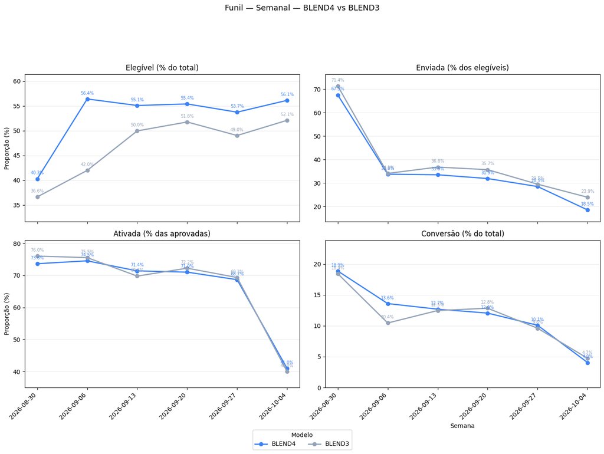

## Funil sem o Rating E do Blend3

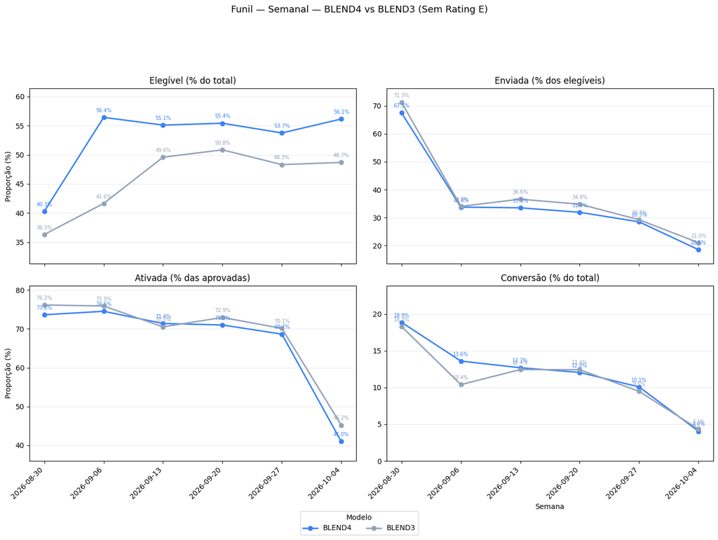

## Tabela de Conversão

Tabela de Conversão com Mix, Elegibilidade, Envio, Ativação, Conversão e Diferença de Conversão entre os modelos Blend3 e Blend4 em números e em percentual.

| bureau_nm_ajust year_week | mix BLEND3 | mix BLEND4 | elegivel BLEND3 | elegivel BLEND4 | enviada_elegivel BLEND3 | enviada_elegivel BLEND4 | ativada BLEND3 | ativada BLEND4 | conversao BLEND3 | conversao BLEND4 | diff_conversao |
| --- | --- | --- | --- | --- | --- | --- | --- | --- | --- | --- | --- |
| 2026-08-30 | 10,936 | 10,191 | 4,004 | 4,104 | 2,857 | 2,771 | 2,015 | 1,922 | 2,015 | 1,922 | -93 |
| 2026-09-06 | 10,765 | 14,761 | 4,519 | 8,328 | 1,541 | 2,812 | 1,124 | 2,005 | 1,124 | 2,005 | 881 |
| 2026-09-13 | 3,483 | 29,921 | 1,740 | 16,486 | 640 | 5,525 | 434 | 3,794 | 434 | 3,794 | 3,360 |
| 2026-09-20 | 3,367 | 29,427 | 1,743 | 16,306 | 622 | 5,202 | 432 | 3,544 | 432 | 3,544 | 3,112 |
| 2026-09-27 | 3,347 | 29,450 | 1,641 | 15,829 | 484 | 4,510 | 321 | 2,965 | 321 | 2,965 | 2,644 |
| 2026-10-04 | 762 | 6,509 | 397 | 3,654 | 95 | 677 | 36 | 263 | 36 | 263 | 227 |

| bureau_nm_ajust year_week | mix BLEND3 | mix BLEND4 | %_elegivel BLEND3 | %_elegivel BLEND4 | %_enviada_elegivel BLEND3 | %_enviada_elegivel BLEND4 | %_ativada BLEND3 | %_ativada BLEND4 | %_conversao BLEND3 | %_conversao BLEND4 | diff_conversao |
| --- | --- | --- | --- | --- | --- | --- | --- | --- | --- | --- | --- |
| 2026-08-30 | 51.76% | 48.24% | 36.61% | 40.27% | 71.35% | 67.52% | 76.01% | 73.64% | 18.43% | 18.86% | +0.43 pp |
| 2026-09-06 | 42.17% | 57.83% | 41.98% | 56.42% | 34.10% | 33.77% | 75.54% | 74.54% | 10.44% | 13.58% | +3.14 pp |
| 2026-09-13 | 10.43% | 89.57% | 49.96% | 55.10% | 36.78% | 33.51% | 69.77% | 71.40% | 12.46% | 12.68% | +0.22 pp |
| 2026-09-20 | 10.27% | 89.73% | 51.77% | 55.41% | 35.69% | 31.90% | 72.24% | 71.01% | 12.83% | 12.04% | -0.79 pp |
| 2026-09-27 | 10.21% | 89.79% | 49.03% | 53.75% | 29.49% | 28.49% | 69.33% | 68.65% | 9.59% | 10.07% | +0.48 pp |
| 2026-10-04 | 10.48% | 89.52% | 52.10% | 56.14% | 23.93% | 18.53% | 40.00% | 40.97% | 4.72% | 4.04% | -0.68 pp |

## Tabela de Conversão sem o Rating E

Tabela de Conversão com Mix, Elegibilidade, Envio, Ativação, Conversão e Diferença de Conversão entre os modelos Blend3 e Blend4 em números e em percentual, retirando o público com RATING E.

| bureau_nm_ajust year_week | mix BLEND3 | mix BLEND4 | elegivel BLEND3 | elegivel BLEND4 | enviada_elegivel BLEND3 | enviada_elegivel BLEND4 | ativada BLEND3 | ativada BLEND4 | conversao BLEND3 | conversao BLEND4 | diff_conversao |
| --- | --- | --- | --- | --- | --- | --- | --- | --- | --- | --- | --- |
| 2026-08-30 | 10,936 | 10,191 | 3,970 | 4,104 | 2,830 | 2,771 | 2,001 | 1,922 | 2,001 | 1,922 | -79 |
| 2026-09-06 | 10,765 | 14,761 | 4,483 | 8,328 | 1,526 | 2,812 | 1,118 | 2,005 | 1,118 | 2,005 | 887 |
| 2026-09-13 | 3,483 | 29,921 | 1,727 | 16,486 | 632 | 5,525 | 433 | 3,794 | 433 | 3,794 | 3,361 |
| 2026-09-20 | 3,367 | 29,427 | 1,712 | 16,306 | 596 | 5,202 | 418 | 3,544 | 418 | 3,544 | 3,126 |
| 2026-09-27 | 3,347 | 29,450 | 1,617 | 15,829 | 473 | 4,510 | 317 | 2,965 | 317 | 2,965 | 2,648 |
| 2026-10-04 | 762 | 6,509 | 371 | 3,654 | 78 | 677 | 33 | 263 | 33 | 263 | 230 |

| bureau_nm_ajust year_week | mix BLEND3 | mix BLEND4 | %_elegivel BLEND3 | %_elegivel BLEND4 | %_enviada_elegivel BLEND3 | %_enviada_elegivel BLEND4 | %_ativada BLEND3 | %_ativada BLEND4 | %_conversao BLEND3 | %_conversao BLEND4 | diff_conversao |
| --- | --- | --- | --- | --- | --- | --- | --- | --- | --- | --- | --- |
| 2026-08-30 | 51.76% | 48.24% | 36.30% | 40.27% | 71.28% | 67.52% | 76.17% | 73.64% | 18.30% | 18.86% | +0.56 pp |
| 2026-09-06 | 42.17% | 57.83% | 41.64% | 56.42% | 34.04% | 33.77% | 75.90% | 74.54% | 10.39% | 13.58% | +3.20 pp |
| 2026-09-13 | 10.43% | 89.57% | 49.58% | 55.10% | 36.60% | 33.51% | 70.52% | 71.40% | 12.43% | 12.68% | +0.25 pp |
| 2026-09-20 | 10.27% | 89.73% | 50.85% | 55.41% | 34.81% | 31.90% | 72.95% | 71.01% | 12.41% | 12.04% | -0.37 pp |
| 2026-09-27 | 10.21% | 89.79% | 48.31% | 53.75% | 29.25% | 28.49% | 70.13% | 68.65% | 9.47% | 10.07% | +0.60 pp |
| 2026-10-04 | 10.48% | 89.52% | 48.69% | 56.14% | 21.02% | 18.53% | 45.21% | 40.97% | 4.33% | 4.04% | -0.29 pp |

## Mix de Rating por Modelo: Blend 4 vs. Blend3

Mix de Rating por Modelo, considerando os 5 Rating's comparáveis.

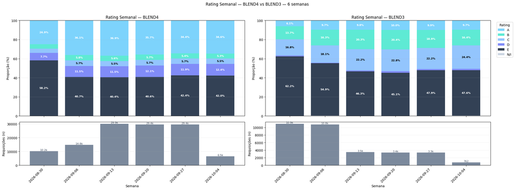

## Mix de Rating Política - Esperado vs. Produção

Mix de Rating de acordo com o Classe Política, ou seja, com maior detalhamento de Rating (A+ e B+, por exemplo). Nesse caso, comparamos com o que era esperado no desenvolvimento do Modelo Blend4. Temos a tabela com o Mix de Rating ao longo do Desenvolvimento e OOT e o gráfico que compara o último mês da OOT (2025-08) com os resultados em Produção.

|  | safra | 1.A+ | 2.A | 3.B+ | 4.B | 5.C | 6.D+ | 7.D | 8.E | 9.E-BVS | volume |
| --- | --- | --- | --- | --- | --- | --- | --- | --- | --- | --- | --- |
| 11 | 2025-08 | 5.479852 | 11.252605 | 11.238394 | 11.356029 | 5.729331 | 5.888019 | 12.401314 | 26.162919 | 10.491537 | 126664 |

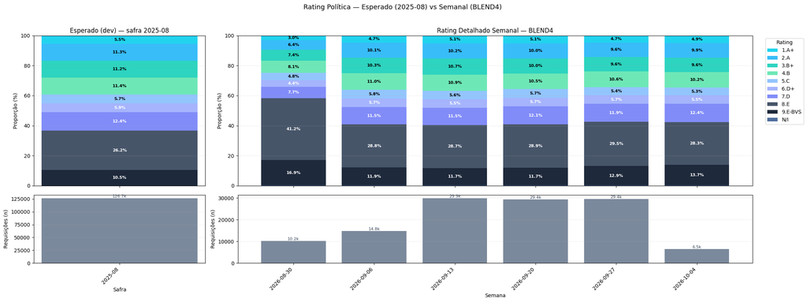

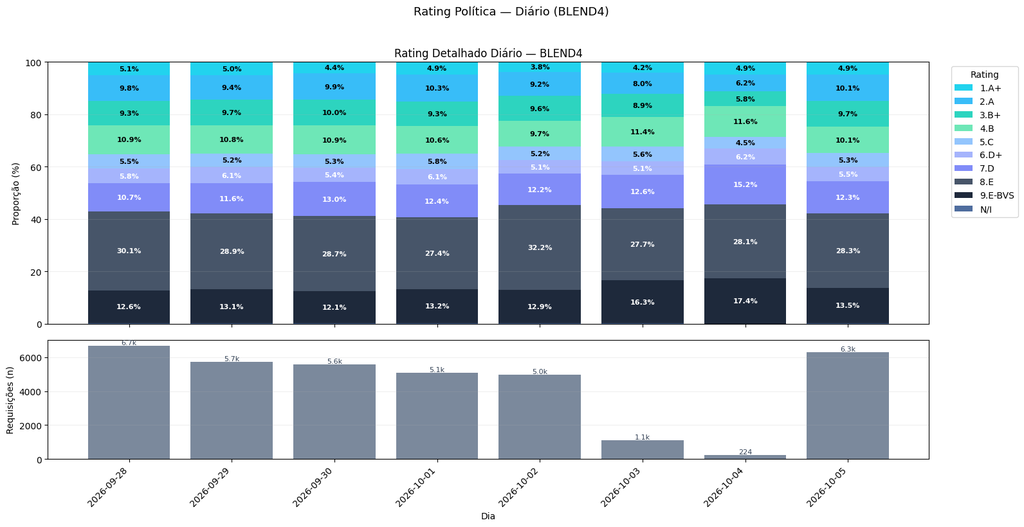

## Funil por Rating

Funil de Elegibilidade, Envio e Conversão comparado por Rating (A, B, C, D e E) em cada um dos Modelos: Blend3 e Blend4.

```
=== Elegível (%) — Semanal — por rating ===
```

| period | Blend 3 Rating A | Blend 3 Rating B | Blend 3 Rating C | Blend 3 Rating D | Blend 3 Rating E | Blend 4 Rating A | Blend 4 Rating B | Blend 4 Rating C | Blend 4 Rating D | Blend 4 Rating E | Blend 4 Rating N/I |
| --- | --- | --- | --- | --- | --- | --- | --- | --- | --- | --- | --- |
| 2026-08-30 | 97.1 | 94.9 | 96.4 | 96.7 | 0.5 | 95.7 | 97.1 | 93.5 | 95.9 | 0.5 | 100.0 |
| 2026-09-06 | 97.7 | 92.7 | 89.2 | 90.7 | 0.6 | 96.4 | 91.6 | 92.8 | 91.9 | 0.7 | 100.0 |
| 2026-09-13 | 96.8 | 93.8 | 89.3 | 90.0 | 0.8 | 95.7 | 89.0 | 87.0 | 82.3 | 1.0 | 100.0 |
| 2026-09-20 | 97.9 | 92.7 | 91.8 | 71.4 | 2.0 | 96.0 | 90.7 | 86.5 | 84.1 | 1.7 | 100.0 |
| 2026-09-27 | 95.2 | 94.3 | 90.2 | 94.3 | 1.5 | 95.8 | 91.4 | 85.6 | 84.5 | 1.8 | 100.0 |
| 2026-10-04 | 98.6 | 96.0 | 88.2 | 100.0 | 7.2 | 96.1 | 91.0 | 88.3 | 84.6 | 5.9 | 100.0 |

```
=== Envio (%) — Semanal — por rating ===
```

| period | Blend 3 Rating A | Blend 3 Rating B | Blend 3 Rating C | Blend 3 Rating D | Blend 3 Rating E | Blend 4 Rating A | Blend 4 Rating B | Blend 4 Rating C | Blend 4 Rating D | Blend 4 Rating E | Blend 4 Rating N/I |
| --- | --- | --- | --- | --- | --- | --- | --- | --- | --- | --- | --- |
| 2026-08-30 | 68.8 | 70.2 | 74.0 | 68.1 | 79.4 | 70.8 | 74.2 | 70.9 | 51.3 | 77.8 | 0.0 |
| 2026-09-06 | 29.1 | 35.0 | 36.3 | 36.8 | 41.7 | 36.2 | 39.9 | 35.1 | 21.5 | 60.5 | 5.0 |
| 2026-09-13 | 26.7 | 35.4 | 42.4 | 44.4 | 61.5 | 34.4 | 40.3 | 37.4 | 24.7 | 40.2 | 0.0 |
| 2026-09-20 | 26.7 | 34.9 | 38.3 | 40.0 | 83.9 | 32.9 | 37.7 | 35.4 | 22.4 | 61.0 | 0.0 |
| 2026-09-27 | 26.3 | 28.9 | 30.7 | 36.4 | 45.8 | 29.3 | 34.1 | 31.9 | 21.6 | 30.8 | 0.0 |
| 2026-10-04 | 13.7 | 21.7 | 23.8 | 25.0 | 65.4 | 17.2 | 21.7 | 18.4 | 13.9 | 51.2 | 0.0 |

```
=== Conversão (%) — Semanal — por rating ===
```

| period | Blend 3 Rating A | Blend 3 Rating B | Blend 3 Rating C | Blend 3 Rating D | Blend 3 Rating E | Blend 4 Rating A | Blend 4 Rating B | Blend 4 Rating C | Blend 4 Rating D | Blend 4 Rating E | Blend 4 Rating N/I |
| --- | --- | --- | --- | --- | --- | --- | --- | --- | --- | --- | --- |
| 2026-08-30 | 48.0 | 50.7 | 47.7 | 39.2 | 0.2 | 49.5 | 50.5 | 41.3 | 28.2 | 0.3 | 0.0 |
| 2026-09-06 | 21.5 | 24.2 | 23.1 | 22.7 | 0.1 | 26.3 | 26.6 | 20.2 | 11.6 | 0.1 | 0.0 |
| 2026-09-13 | 17.4 | 23.6 | 25.6 | 22.5 | 0.1 | 23.3 | 25.1 | 21.8 | 12.0 | 0.2 | 0.0 |
| 2026-09-20 | 19.3 | 22.0 | 25.1 | 16.1 | 0.9 | 22.5 | 24.0 | 19.6 | 10.8 | 0.5 | 0.0 |
| 2026-09-27 | 18.1 | 18.2 | 18.3 | 17.1 | 0.2 | 19.3 | 21.6 | 16.8 | 10.2 | 0.2 | 0.0 |
| 2026-10-04 | 4.1 | 9.6 | 8.6 | 16.7 | 0.8 | 7.6 | 7.8 | 4.5 | 4.2 | 0.5 | 0.0 |

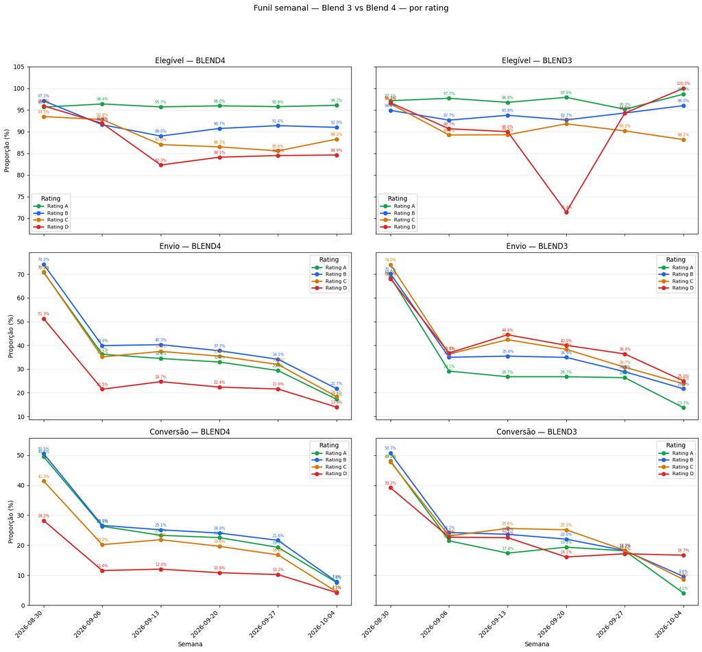

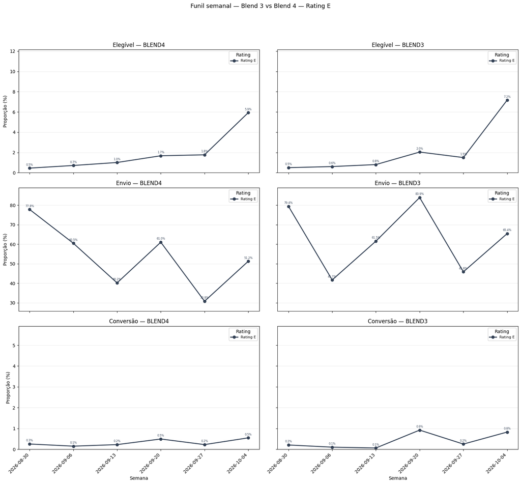

## Pré-Análise por Rating

Pré Análise (Aprovar, Derivar e Reprovar) aberto por Rating (A, B, C, D e E) e comparando os Modelos Blend3 e Blend4.

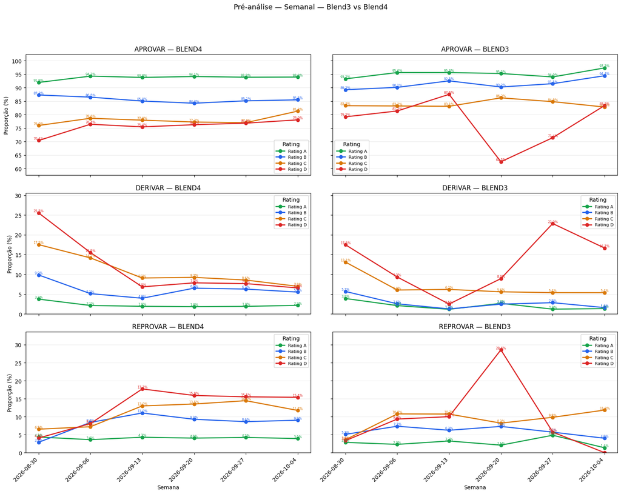

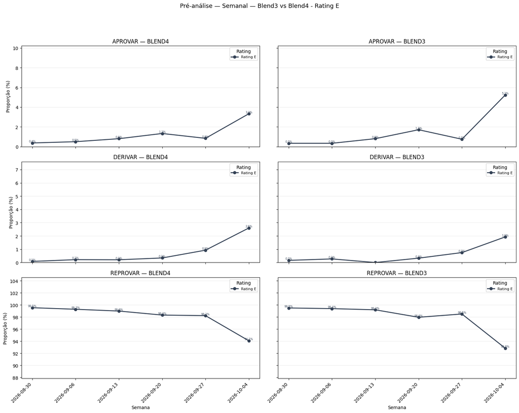

## Conversão Aprovados

```
Semanas: ['2026-08-30', '2026-09-06', '2026-09-13', '2026-09-20', '2026-09-27', '2026-10-04']
```

Baseline — Semana 2026-09-27

**Leads (Counts)**

| modelo decisao rating_score_group | BLEND3 APROVADO | BLEND3 DERIVADO | BLEND3 REPROVADO | BLEND4 APROVADO | BLEND4 DERIVADO | BLEND4 REPROVADO |
| --- | --- | --- | --- | --- | --- | --- |
| A | 311 | 4 | 16 | 9,520 | 194 | 429 |
| B | 578 | 18 | 36 | 1,354 | 100 | 137 |
| C | 630 | 40 | 73 | 1,285 | 143 | 241 |
| D | 25 | 8 | 2 | 2,694 | 269 | 544 |
| E | 12 | 12 | 1,579 | 105 | 116 | 12,270 |
| N/I | 0 | 3 | 0 | 0 | 49 | 0 |
| Total | 1,556 | 85 | 1,706 | 14,958 | 871 | 13,621 |

**Ativado / Lead (%)**

| modelo decisao rating_score_group | BLEND3 APROVADO | BLEND3 DERIVADO | BLEND3 REPROVADO | BLEND4 APROVADO | BLEND4 DERIVADO | BLEND4 REPROVADO |
| --- | --- | --- | --- | --- | --- | --- |
| A | 19.0% | 25.0% | 0.0% | 20.4% | 5.2% | 0.0% |
| B | 19.7% | 5.6% | 0.0% | 25.3% | 1.0% | 0.0% |
| C | 21.4% | 2.5% | 0.0% | 21.6% | 2.1% | 0.0% |
| D | 24.0% | 0.0% | 0.0% | 13.2% | 0.7% | 0.0% |
| E | 33.3% | 0.0% | 0.0% | 25.7% | 0.9% | 0.0% |
| N/I | nan% | 0.0% | nan% | nan% | 0.0% | nan% |
| Total | 20.4% | 3.5% | 0.0% | 19.7% | 2.0% | 0.0% |

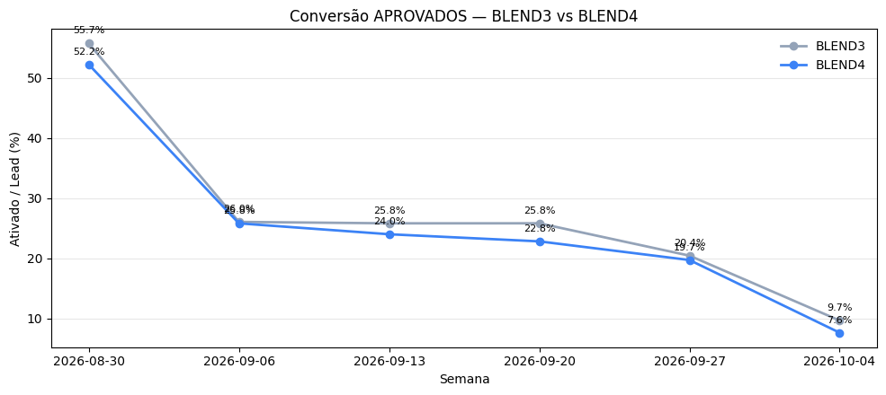

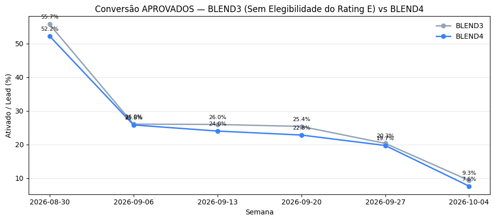

## Acompanhamento Renda

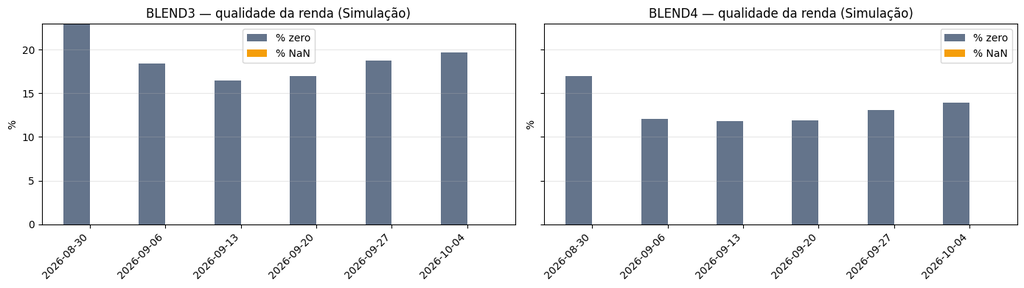

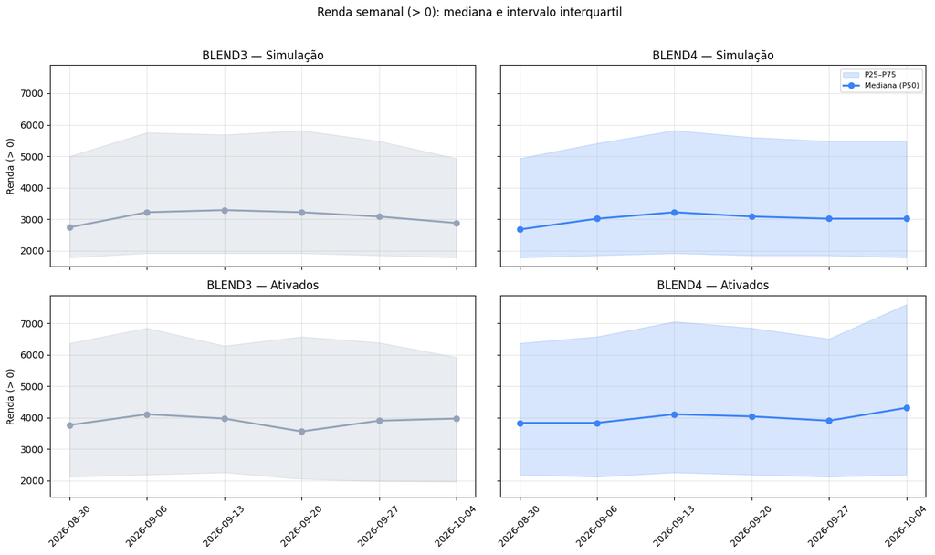

| rating_score_ds | contract_id |
| --- | --- |
| 8.E | 2 |
| 9.E-BVS | 15113 |
| N/I | 180 |

```
'bureau_nm_ajust'
```

## Mix de Cidades

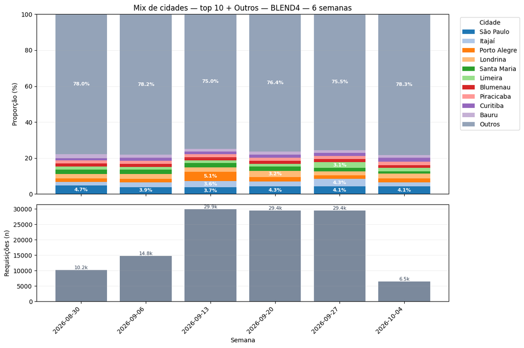

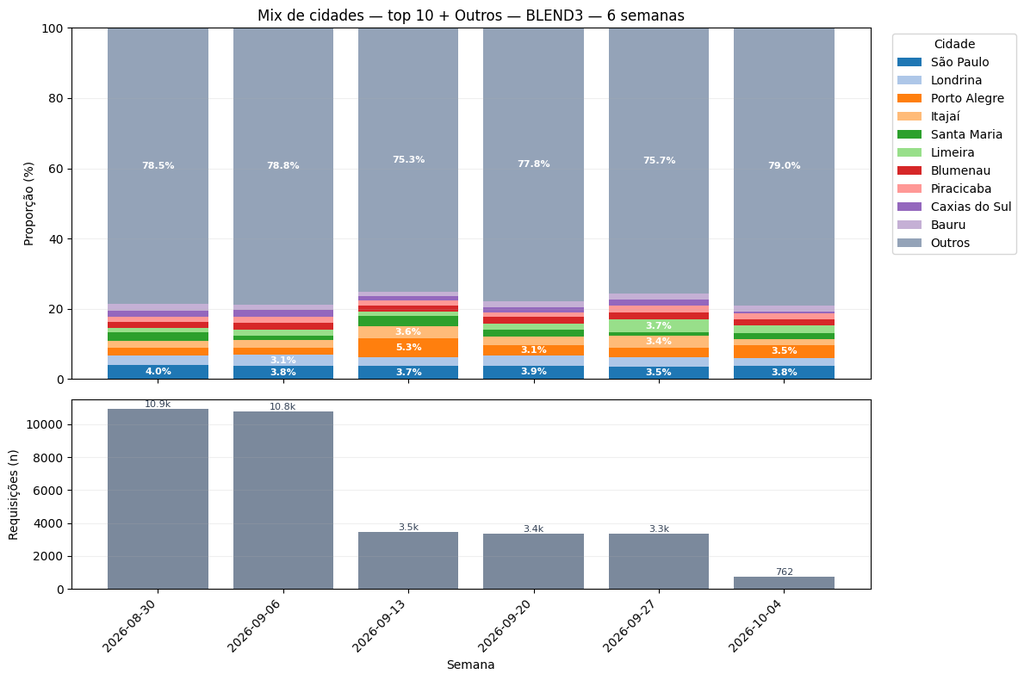

```
=== Cidades — BLEND4 | 2026-09-27 → 2026-10-04 ===
Já existiam e subiram para o top 10
```

|  | week_prev | week_curr | entity | n_prev | n_curr | share_prev_pct | share_curr_pct | delta_pp | rank_prev | rank_curr | rank_gain |
| --- | --- | --- | --- | --- | --- | --- | --- | --- | --- | --- | --- |
| 56 | 2026-09-27 | 2026-10-04 | Jacareí | 310 | 193 | 1.05 | 2.97 | 1.91 | 20 | 2 | 18 |
| 57 | 2026-09-27 | 2026-10-04 | Camboriú | 340 | 127 | 1.15 | 1.95 | 0.80 | 16 | 8 | 8 |
| 58 | 2026-09-27 | 2026-10-04 | Caxias do Sul | 398 | 118 | 1.35 | 1.81 | 0.46 | 11 | 10 | 1 |

```
Novas no top 10 (não estavam na semana anterior): nenhuma
Saíram do top 10
```

|  | week_prev | week_curr | entity | n_prev | n_curr | share_prev_pct | share_curr_pct | delta_pp | rank_prev | rank_curr | rank_gain |
| --- | --- | --- | --- | --- | --- | --- | --- | --- | --- | --- | --- |
| 55 | 2026-09-27 | 2026-10-04 | Santa Maria | 550 | 82 | 1.87 | 1.26 | -0.61 | 6 | 16 | -10 |
| 54 | 2026-09-27 | 2026-10-04 | Blumenau | 537 | 105 | 1.82 | 1.61 | -0.21 | 7 | 13 | -6 |
| 53 | 2026-09-27 | 2026-10-04 | Bauru | 454 | 106 | 1.54 | 1.63 | 0.09 | 10 | 12 | -2 |

```
Histórico WoW — Cidades — BLEND4
```

|  | week_prev | week_curr | entity | status | n_prev | n_curr | share_prev_pct | share_curr_pct | delta_pp | rank_prev | rank_curr | rank_gain |
| --- | --- | --- | --- | --- | --- | --- | --- | --- | --- | --- | --- | --- |
| 9 | 2026-08-30 | 2026-09-06 | Goiânia | saiu_do_top | 216 | 185 | 2.12 | 1.25 | -0.87 | 5 | 14 | -9 |
| 10 | 2026-08-30 | 2026-09-06 | Caxias do Sul | subiu_para_top | 136 | 223 | 1.33 | 1.51 | 0.18 | 13 | 10 | 3 |
| 19 | 2026-09-06 | 2026-09-13 | Caxias do Sul | saiu_do_top | 223 | 381 | 1.51 | 1.27 | -0.24 | 10 | 15 | -5 |
| 20 | 2026-09-06 | 2026-09-13 | Bauru | saiu_do_top | 256 | 416 | 1.73 | 1.39 | -0.34 | 8 | 12 | -4 |
| 21 | 2026-09-06 | 2026-09-13 | Florianópolis | subiu_para_top | 151 | 453 | 1.02 | 1.51 | 0.49 | 26 | 10 | 16 |
| 22 | 2026-09-06 | 2026-09-13 | Curitiba | subiu_para_top | 219 | 489 | 1.48 | 1.63 | 0.15 | 11 | 8 | 3 |
| 31 | 2026-09-13 | 2026-09-20 | Florianópolis | saiu_do_top | 453 | 390 | 1.51 | 1.33 | -0.19 | 10 | 12 | -2 |
| 32 | 2026-09-13 | 2026-09-20 | Limeira | saiu_do_top | 492 | 417 | 1.64 | 1.42 | -0.23 | 7 | 11 | -4 |
| 33 | 2026-09-13 | 2026-09-20 | Bauru | subiu_para_top | 416 | 502 | 1.39 | 1.71 | 0.32 | 12 | 9 | 3 |
| 34 | 2026-09-13 | 2026-09-20 | Rio de Janeiro | subiu_para_top | 409 | 451 | 1.37 | 1.53 | 0.17 | 13 | 10 | 3 |
| 44 | 2026-09-20 | 2026-09-27 | Rio de Janeiro | saiu_do_top | 451 | 366 | 1.53 | 1.24 | -0.29 | 10 | 13 | -3 |
| 45 | 2026-09-20 | 2026-09-27 | Limeira | subiu_para_top | 417 | 911 | 1.42 | 3.09 | 1.68 | 11 | 3 | 8 |
| 53 | 2026-09-27 | 2026-10-04 | Bauru | saiu_do_top | 454 | 106 | 1.54 | 1.63 | 0.09 | 10 | 12 | -2 |
| 54 | 2026-09-27 | 2026-10-04 | Blumenau | saiu_do_top | 537 | 105 | 1.82 | 1.61 | -0.21 | 7 | 13 | -6 |
| 55 | 2026-09-27 | 2026-10-04 | Santa Maria | saiu_do_top | 550 | 82 | 1.87 | 1.26 | -0.61 | 6 | 16 | -10 |
| 56 | 2026-09-27 | 2026-10-04 | Jacareí | subiu_para_top | 310 | 193 | 1.05 | 2.97 | 1.91 | 20 | 2 | 18 |
| 57 | 2026-09-27 | 2026-10-04 | Camboriú | subiu_para_top | 340 | 127 | 1.15 | 1.95 | 0.80 | 16 | 8 | 8 |
| 58 | 2026-09-27 | 2026-10-04 | Caxias do Sul | subiu_para_top | 398 | 118 | 1.35 | 1.81 | 0.46 | 11 | 10 | 1 |

```
=== Cidades — BLEND3 | 2026-09-27 → 2026-10-04 ===
Já existiam e subiram para o top 10
```

|  | week_prev | week_curr | entity | n_prev | n_curr | share_prev_pct | share_curr_pct | delta_pp | rank_prev | rank_curr | rank_gain |
| --- | --- | --- | --- | --- | --- | --- | --- | --- | --- | --- | --- |
| 59 | 2026-09-27 | 2026-10-04 | Jacareí | 34 | 30 | 1.02 | 3.94 | 2.92 | 23 | 1.0 | 22.0 |

```
Novas no top 10 (não estavam na semana anterior): nenhuma
Saíram do top 10
```

|  | week_prev | week_curr | entity | n_prev | n_curr | share_prev_pct | share_curr_pct | delta_pp | rank_prev | rank_curr | rank_gain |
| --- | --- | --- | --- | --- | --- | --- | --- | --- | --- | --- | --- |
| 58 | 2026-09-27 | 2026-10-04 | Limeira | 123 | 0 | 3.67 | 0.0 | -3.67 | 1 | NaN | NaN |
| 57 | 2026-09-27 | 2026-10-04 | Itajaí | 114 | 0 | 3.41 | 0.0 | -3.41 | 3 | NaN | NaN |
| 56 | 2026-09-27 | 2026-10-04 | Londrina | 88 | 0 | 2.63 | 0.0 | -2.63 | 5 | NaN | NaN |
| 55 | 2026-09-27 | 2026-10-04 | Piracicaba | 68 | 0 | 2.03 | 0.0 | -2.03 | 6 | NaN | NaN |
| 54 | 2026-09-27 | 2026-10-04 | Blumenau | 67 | 0 | 2.00 | 0.0 | -2.00 | 7 | NaN | NaN |
| 53 | 2026-09-27 | 2026-10-04 | Caxias do Sul | 56 | 0 | 1.67 | 0.0 | -1.67 | 8 | NaN | NaN |
| 52 | 2026-09-27 | 2026-10-04 | Bauru | 55 | 0 | 1.64 | 0.0 | -1.64 | 9 | NaN | NaN |
| 51 | 2026-09-27 | 2026-10-04 | Curitiba | 49 | 0 | 1.46 | 0.0 | -1.46 | 10 | NaN | NaN |

```
Histórico WoW — Cidades — BLEND3
```

|  | week_prev | week_curr | entity | status | n_prev | n_curr | share_prev_pct | share_curr_pct | delta_pp | rank_prev | rank_curr | rank_gain |
| --- | --- | --- | --- | --- | --- | --- | --- | --- | --- | --- | --- | --- |
| 9 | 2026-08-30 | 2026-09-06 | Santa Maria | saiu_do_top | 252 | 139 | 2.30 | 1.29 | -1.01 | 3 | 15.0 | -12.0 |
| 10 | 2026-08-30 | 2026-09-06 | Limeira | subiu_para_top | 156 | 180 | 1.43 | 1.67 | 0.25 | 11 | 8.0 | 3.0 |
| 18 | 2026-09-06 | 2026-09-13 | Limeira | saiu_do_top | 180 | 47 | 1.67 | 1.35 | -0.32 | 8 | 11.0 | -3.0 |
| 19 | 2026-09-06 | 2026-09-13 | Bauru | saiu_do_top | 163 | 38 | 1.51 | 1.09 | -0.42 | 10 | 21.0 | -11.0 |
| 20 | 2026-09-06 | 2026-09-13 | Goiânia | saiu_do_top | 164 | 34 | 1.52 | 0.98 | -0.55 | 9 | 25.0 | -16.0 |
| 21 | 2026-09-06 | 2026-09-13 | Santa Maria | subiu_para_top | 139 | 97 | 1.29 | 2.78 | 1.49 | 15 | 4.0 | 11.0 |
| 22 | 2026-09-06 | 2026-09-13 | Curitiba | subiu_para_top | 153 | 64 | 1.42 | 1.84 | 0.42 | 11 | 6.0 | 5.0 |
| 23 | 2026-09-06 | 2026-09-13 | Gravataí | subiu_para_top | 149 | 58 | 1.38 | 1.67 | 0.28 | 12 | 7.0 | 5.0 |
| 31 | 2026-09-13 | 2026-09-20 | Caxias do Sul | saiu_do_top | 48 | 48 | 1.38 | 1.43 | 0.05 | 10 | 12.0 | -2.0 |
| 32 | 2026-09-13 | 2026-09-20 | Piracicaba | saiu_do_top | 50 | 47 | 1.44 | 1.40 | -0.04 | 9 | 14.0 | -5.0 |
| 33 | 2026-09-13 | 2026-09-20 | Gravataí | saiu_do_top | 58 | 47 | 1.67 | 1.40 | -0.27 | 7 | 14.0 | -7.0 |
| 34 | 2026-09-13 | 2026-09-20 | Bauru | subiu_para_top | 38 | 60 | 1.09 | 1.78 | 0.69 | 21 | 8.0 | 13.0 |
| 35 | 2026-09-13 | 2026-09-20 | Belo Horizonte | subiu_para_top | 42 | 52 | 1.21 | 1.54 | 0.34 | 15 | 10.0 | 5.0 |
| 36 | 2026-09-13 | 2026-09-20 | Limeira | subiu_para_top | 47 | 56 | 1.35 | 1.66 | 0.31 | 11 | 9.0 | 2.0 |
| 45 | 2026-09-20 | 2026-09-27 | Belo Horizonte | saiu_do_top | 52 | 40 | 1.54 | 1.20 | -0.35 | 10 | 15.0 | -5.0 |
| 46 | 2026-09-20 | 2026-09-27 | Santa Maria | saiu_do_top | 69 | 32 | 2.05 | 0.96 | -1.09 | 6 | 24.0 | -18.0 |
| 47 | 2026-09-20 | 2026-09-27 | Piracicaba | subiu_para_top | 47 | 68 | 1.40 | 2.03 | 0.64 | 14 | 6.0 | 8.0 |
| 48 | 2026-09-20 | 2026-09-27 | Caxias do Sul | subiu_para_top | 48 | 56 | 1.43 | 1.67 | 0.25 | 12 | 8.0 | 4.0 |
| 51 | 2026-09-27 | 2026-10-04 | Curitiba | saiu_do_top | 49 | 0 | 1.46 | 0.00 | -1.46 | 10 | NaN | NaN |
| 52 | 2026-09-27 | 2026-10-04 | Bauru | saiu_do_top | 55 | 0 | 1.64 | 0.00 | -1.64 | 9 | NaN | NaN |
| 53 | 2026-09-27 | 2026-10-04 | Caxias do Sul | saiu_do_top | 56 | 0 | 1.67 | 0.00 | -1.67 | 8 | NaN | NaN |
| 54 | 2026-09-27 | 2026-10-04 | Blumenau | saiu_do_top | 67 | 0 | 2.00 | 0.00 | -2.00 | 7 | NaN | NaN |
| 55 | 2026-09-27 | 2026-10-04 | Piracicaba | saiu_do_top | 68 | 0 | 2.03 | 0.00 | -2.03 | 6 | NaN | NaN |
| 56 | 2026-09-27 | 2026-10-04 | Londrina | saiu_do_top | 88 | 0 | 2.63 | 0.00 | -2.63 | 5 | NaN | NaN |
| 57 | 2026-09-27 | 2026-10-04 | Itajaí | saiu_do_top | 114 | 0 | 3.41 | 0.00 | -3.41 | 3 | NaN | NaN |
| 58 | 2026-09-27 | 2026-10-04 | Limeira | saiu_do_top | 123 | 0 | 3.67 | 0.00 | -3.67 | 1 | NaN | NaN |
| 59 | 2026-09-27 | 2026-10-04 | Jacareí | subiu_para_top | 34 | 30 | 1.02 | 3.94 | 2.92 | 23 | 1.0 | 22.0 |

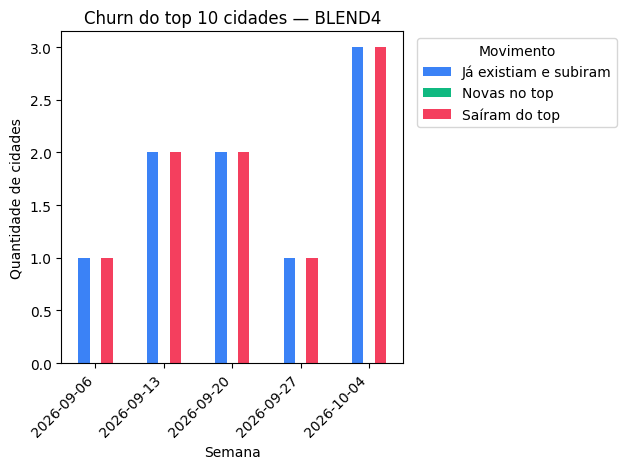

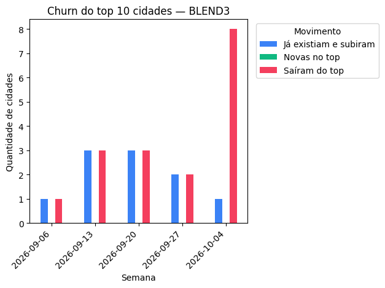

Trazer Estados ao invés da Cidade

## Mix de Imobiliárias

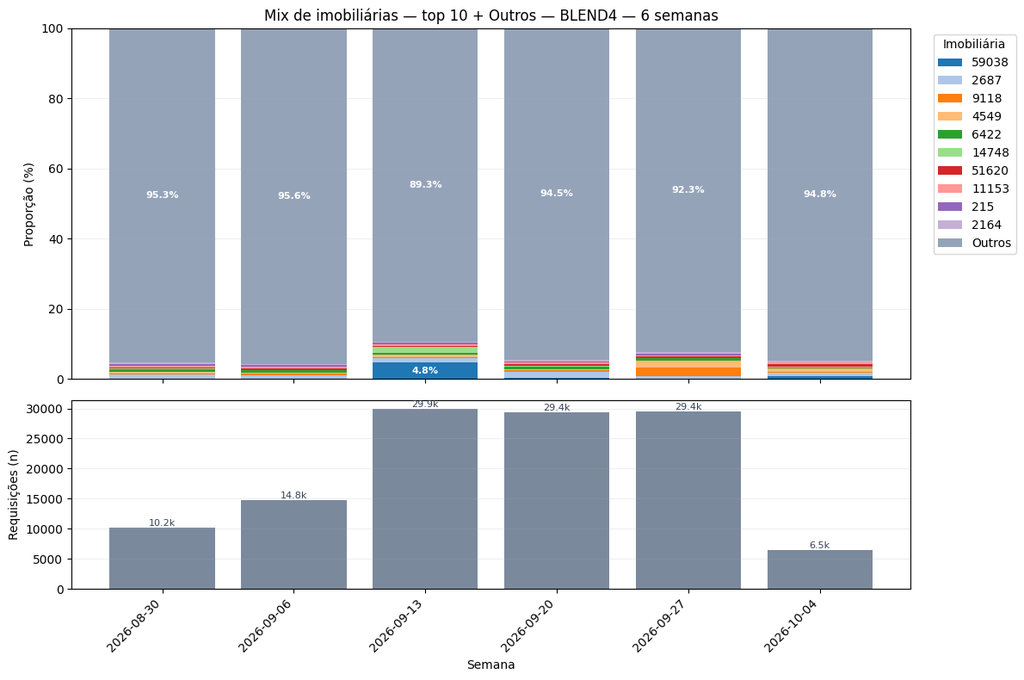

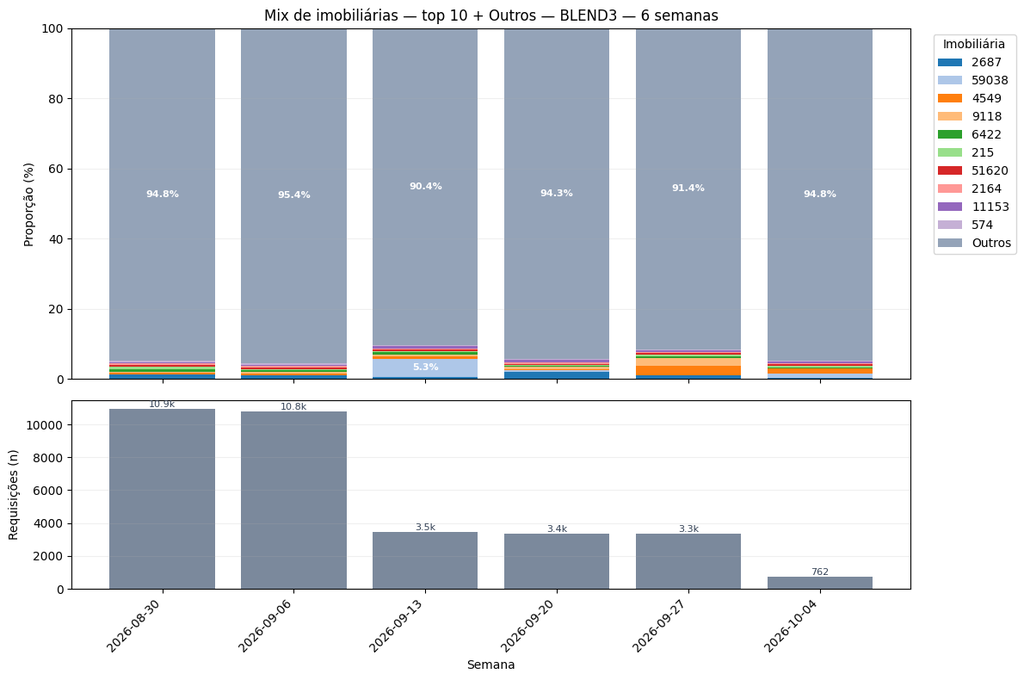

```
=== Imobiliárias — BLEND4 | 2026-09-27 → 2026-10-04 ===
Já existiam e subiram para o top 10
```

|  | week_prev | week_curr | entity | n_prev | n_curr | share_prev_pct | share_curr_pct | delta_pp | rank_prev | rank_curr | rank_gain |
| --- | --- | --- | --- | --- | --- | --- | --- | --- | --- | --- | --- |
| 74 | 2026-09-27 | 2026-10-04 | 3636 | 31 | 132 | 0.11 | 2.03 | 1.92 | 117.0 | 1.0 | 116.0 |
| 75 | 2026-09-27 | 2026-10-04 | 53646 | 72 | 43 | 0.24 | 0.66 | 0.42 | 27.0 | 7.0 | 20.0 |
| 76 | 2026-09-27 | 2026-10-04 | 1225 | 76 | 26 | 0.26 | 0.40 | 0.14 | 24.0 | 10.0 | 14.0 |

```
Novas no top 10 (não estavam na semana anterior)
```

|  | week_prev | week_curr | entity | n_prev | n_curr | share_prev_pct | share_curr_pct | delta_pp | rank_prev | rank_curr | rank_gain |
| --- | --- | --- | --- | --- | --- | --- | --- | --- | --- | --- | --- |
| 62 | 2026-09-27 | 2026-10-04 | 2042 | 0 | 50 | 0.0 | 0.77 | 0.77 | NaN | 4.0 | NaN |
| 63 | 2026-09-27 | 2026-10-04 | 59038 | 0 | 50 | 0.0 | 0.77 | 0.77 | NaN | 4.0 | NaN |

```
Saíram do top 10
```

|  | week_prev | week_curr | entity | n_prev | n_curr | share_prev_pct | share_curr_pct | delta_pp | rank_prev | rank_curr | rank_gain |
| --- | --- | --- | --- | --- | --- | --- | --- | --- | --- | --- | --- |
| 73 | 2026-09-27 | 2026-10-04 | 9118 | 714 | 25 | 2.42 | 0.38 | -2.04 | 1.0 | 11.0 | -10.0 |
| 72 | 2026-09-27 | 2026-10-04 | 215 | 136 | 0 | 0.46 | 0.00 | -0.46 | 6.0 | NaN | NaN |
| 71 | 2026-09-27 | 2026-10-04 | 6360 | 101 | 0 | 0.34 | 0.00 | -0.34 | 10.0 | NaN | NaN |
| 70 | 2026-09-27 | 2026-10-04 | 6422 | 173 | 23 | 0.59 | 0.35 | -0.23 | 4.0 | 14.0 | -10.0 |
| 69 | 2026-09-27 | 2026-10-04 | 389 | 137 | 23 | 0.47 | 0.35 | -0.11 | 5.0 | 14.0 | -9.0 |

```
Histórico WoW — Imobiliárias — BLEND4
```

|  | week_prev | week_curr | entity | status | n_prev | n_curr | share_prev_pct | share_curr_pct | delta_pp | rank_prev | rank_curr | rank_gain |
| --- | --- | --- | --- | --- | --- | --- | --- | --- | --- | --- | --- | --- |
| 0 | 2026-08-30 | 2026-09-06 | 264 | nova_no_top | 0 | 57 | 0.00 | 0.39 | 0.39 | NaN | 10.0 | NaN |
| 6 | 2026-08-30 | 2026-09-06 | 13380 | saiu_do_top | 49 | 56 | 0.48 | 0.38 | -0.10 | 7.0 | 11.0 | -4.0 |
| 7 | 2026-08-30 | 2026-09-06 | 215 | saiu_do_top | 54 | 53 | 0.53 | 0.36 | -0.17 | 4.0 | 13.0 | -9.0 |
| 8 | 2026-08-30 | 2026-09-06 | 4549 | saiu_do_top | 50 | 39 | 0.49 | 0.26 | -0.23 | 5.0 | 26.0 | -21.0 |
| 9 | 2026-08-30 | 2026-09-06 | 549 | saiu_do_top | 50 | 30 | 0.49 | 0.20 | -0.29 | 5.0 | 48.0 | -43.0 |
| 10 | 2026-08-30 | 2026-09-06 | 713 | saiu_do_top | 67 | 0 | 0.66 | 0.00 | -0.66 | 3.0 | NaN | NaN |
| 11 | 2026-08-30 | 2026-09-06 | 1225 | subiu_para_top | 28 | 62 | 0.27 | 0.42 | 0.15 | 26.0 | 9.0 | 17.0 |
| 12 | 2026-08-30 | 2026-09-06 | 9118 | subiu_para_top | 32 | 67 | 0.31 | 0.45 | 0.14 | 17.0 | 5.0 | 12.0 |
| 13 | 2026-08-30 | 2026-09-06 | 574 | subiu_para_top | 37 | 65 | 0.36 | 0.44 | 0.08 | 12.0 | 6.0 | 6.0 |
| 14 | 2026-08-30 | 2026-09-06 | 11153 | subiu_para_top | 37 | 64 | 0.36 | 0.43 | 0.07 | 12.0 | 8.0 | 4.0 |
| 15 | 2026-09-06 | 2026-09-13 | 59038 | nova_no_top | 0 | 1451 | 0.00 | 4.85 | 4.85 | NaN | 1.0 | NaN |
| 16 | 2026-09-06 | 2026-09-13 | 14748 | nova_no_top | 0 | 487 | 0.00 | 1.63 | 1.63 | NaN | 2.0 | NaN |
| 21 | 2026-09-06 | 2026-09-13 | 264 | saiu_do_top | 57 | 106 | 0.39 | 0.35 | -0.03 | 10.0 | 15.0 | -5.0 |
| 22 | 2026-09-06 | 2026-09-13 | 9118 | saiu_do_top | 67 | 110 | 0.45 | 0.37 | -0.09 | 5.0 | 13.0 | -8.0 |
| 23 | 2026-09-06 | 2026-09-13 | 1225 | saiu_do_top | 62 | 99 | 0.42 | 0.33 | -0.09 | 9.0 | 16.0 | -7.0 |
| 24 | 2026-09-06 | 2026-09-13 | 2164 | saiu_do_top | 65 | 97 | 0.44 | 0.32 | -0.12 | 6.0 | 19.0 | -13.0 |
| 25 | 2026-09-06 | 2026-09-13 | 574 | saiu_do_top | 65 | 95 | 0.44 | 0.32 | -0.12 | 6.0 | 22.0 | -16.0 |
| 26 | 2026-09-06 | 2026-09-13 | 40682 | saiu_do_top | 71 | 99 | 0.48 | 0.33 | -0.15 | 4.0 | 16.0 | -12.0 |
| 27 | 2026-09-06 | 2026-09-13 | 4549 | subiu_para_top | 39 | 221 | 0.26 | 0.74 | 0.47 | 26.0 | 4.0 | 22.0 |
| 28 | 2026-09-06 | 2026-09-13 | 969 | subiu_para_top | 39 | 205 | 0.26 | 0.69 | 0.42 | 26.0 | 5.0 | 21.0 |
| 29 | 2026-09-06 | 2026-09-13 | 12289 | subiu_para_top | 21 | 119 | 0.14 | 0.40 | 0.26 | 86.0 | 9.0 | 77.0 |
| 30 | 2026-09-06 | 2026-09-13 | 4094 | subiu_para_top | 34 | 119 | 0.23 | 0.40 | 0.17 | 42.0 | 9.0 | 33.0 |
| 31 | 2026-09-06 | 2026-09-13 | 17378 | subiu_para_top | 45 | 125 | 0.30 | 0.42 | 0.11 | 16.0 | 8.0 | 8.0 |
| 32 | 2026-09-06 | 2026-09-13 | 215 | subiu_para_top | 53 | 119 | 0.36 | 0.40 | 0.04 | 13.0 | 9.0 | 4.0 |
| 40 | 2026-09-13 | 2026-09-20 | 51620 | saiu_do_top | 119 | 108 | 0.40 | 0.37 | -0.03 | 9.0 | 12.0 | -3.0 |
| 41 | 2026-09-13 | 2026-09-20 | 12289 | saiu_do_top | 119 | 0 | 0.40 | 0.00 | -0.40 | 9.0 | NaN | NaN |
| 42 | 2026-09-13 | 2026-09-20 | 969 | saiu_do_top | 205 | 66 | 0.69 | 0.22 | -0.46 | 5.0 | 36.0 | -31.0 |
| 43 | 2026-09-13 | 2026-09-20 | 14748 | saiu_do_top | 487 | 70 | 1.63 | 0.24 | -1.39 | 2.0 | 30.0 | -28.0 |
| 44 | 2026-09-13 | 2026-09-20 | 59038 | saiu_do_top | 1451 | 95 | 4.85 | 0.32 | -4.53 | 1.0 | 17.0 | -16.0 |
| 45 | 2026-09-13 | 2026-09-20 | 9118 | subiu_para_top | 110 | 147 | 0.37 | 0.50 | 0.13 | 13.0 | 3.0 | 10.0 |
| 46 | 2026-09-13 | 2026-09-20 | 2164 | subiu_para_top | 97 | 126 | 0.32 | 0.43 | 0.10 | 19.0 | 6.0 | 13.0 |
| 47 | 2026-09-13 | 2026-09-20 | 389 | subiu_para_top | 96 | 120 | 0.32 | 0.41 | 0.09 | 21.0 | 8.0 | 13.0 |
| 54 | 2026-09-20 | 2026-09-27 | 2164 | saiu_do_top | 126 | 97 | 0.43 | 0.33 | -0.10 | 6.0 | 13.0 | -7.0 |
| 55 | 2026-09-20 | 2026-09-27 | 11153 | saiu_do_top | 138 | 96 | 0.47 | 0.33 | -0.14 | 4.0 | 14.0 | -10.0 |
| 56 | 2026-09-20 | 2026-09-27 | 4094 | saiu_do_top | 133 | 86 | 0.45 | 0.29 | -0.16 | 5.0 | 18.0 | -13.0 |
| 57 | 2026-09-20 | 2026-09-27 | 17378 | saiu_do_top | 121 | 52 | 0.41 | 0.18 | -0.23 | 7.0 | 41.0 | -34.0 |
| 58 | 2026-09-20 | 2026-09-27 | 6360 | subiu_para_top | 70 | 101 | 0.24 | 0.34 | 0.11 | 30.0 | 10.0 | 20.0 |
| 59 | 2026-09-20 | 2026-09-27 | 51620 | subiu_para_top | 108 | 121 | 0.37 | 0.41 | 0.04 | 12.0 | 7.0 | 5.0 |
| 60 | 2026-09-20 | 2026-09-27 | 264 | subiu_para_top | 97 | 102 | 0.33 | 0.35 | 0.02 | 15.0 | 9.0 | 6.0 |
| 61 | 2026-09-20 | 2026-09-27 | 4881 | subiu_para_top | 114 | 103 | 0.39 | 0.35 | -0.04 | 11.0 | 8.0 | 3.0 |
| 62 | 2026-09-27 | 2026-10-04 | 2042 | nova_no_top | 0 | 50 | 0.00 | 0.77 | 0.77 | NaN | 4.0 | NaN |
| 63 | 2026-09-27 | 2026-10-04 | 59038 | nova_no_top | 0 | 50 | 0.00 | 0.77 | 0.77 | NaN | 4.0 | NaN |
| 69 | 2026-09-27 | 2026-10-04 | 389 | saiu_do_top | 137 | 23 | 0.47 | 0.35 | -0.11 | 5.0 | 14.0 | -9.0 |
| 70 | 2026-09-27 | 2026-10-04 | 6422 | saiu_do_top | 173 | 23 | 0.59 | 0.35 | -0.23 | 4.0 | 14.0 | -10.0 |
| 71 | 2026-09-27 | 2026-10-04 | 6360 | saiu_do_top | 101 | 0 | 0.34 | 0.00 | -0.34 | 10.0 | NaN | NaN |
| 72 | 2026-09-27 | 2026-10-04 | 215 | saiu_do_top | 136 | 0 | 0.46 | 0.00 | -0.46 | 6.0 | NaN | NaN |
| 73 | 2026-09-27 | 2026-10-04 | 9118 | saiu_do_top | 714 | 25 | 2.42 | 0.38 | -2.04 | 1.0 | 11.0 | -10.0 |
| 74 | 2026-09-27 | 2026-10-04 | 3636 | subiu_para_top | 31 | 132 | 0.11 | 2.03 | 1.92 | 117.0 | 1.0 | 116.0 |
| 75 | 2026-09-27 | 2026-10-04 | 53646 | subiu_para_top | 72 | 43 | 0.24 | 0.66 | 0.42 | 27.0 | 7.0 | 20.0 |
| 76 | 2026-09-27 | 2026-10-04 | 1225 | subiu_para_top | 76 | 26 | 0.26 | 0.40 | 0.14 | 24.0 | 10.0 | 14.0 |

```
=== Imobiliárias — BLEND3 | 2026-09-27 → 2026-10-04 ===
Já existiam e subiram para o top 10: nenhuma
Novas no top 10 (não estavam na semana anterior): nenhuma
Saíram do top 10
```

|  | week_prev | week_curr | entity | n_prev | n_curr | share_prev_pct | share_curr_pct | delta_pp | rank_prev | rank_curr | rank_gain |
| --- | --- | --- | --- | --- | --- | --- | --- | --- | --- | --- | --- |
| 46 | 2026-09-27 | 2026-10-04 | 4549 | 91 | 0 | 2.72 | 0.0 | -2.72 | 1.0 | NaN | NaN |
| 45 | 2026-09-27 | 2026-10-04 | 9118 | 74 | 0 | 2.21 | 0.0 | -2.21 | 2.0 | NaN | NaN |
| 44 | 2026-09-27 | 2026-10-04 | 2687 | 36 | 0 | 1.08 | 0.0 | -1.08 | 3.0 | NaN | NaN |
| 43 | 2026-09-27 | 2026-10-04 | 215 | 22 | 0 | 0.66 | 0.0 | -0.66 | 4.0 | NaN | NaN |

```
Histórico WoW — Imobiliárias — BLEND3
```

|  | week_prev | week_curr | entity | status | n_prev | n_curr | share_prev_pct | share_curr_pct | delta_pp | rank_prev | rank_curr | rank_gain |
| --- | --- | --- | --- | --- | --- | --- | --- | --- | --- | --- | --- | --- |
| 0 | 2026-08-30 | 2026-09-06 | 35245 | nova_no_top | 0 | 45 | 0.00 | 0.42 | 0.42 | NaN | 9.0 | NaN |
| 5 | 2026-08-30 | 2026-09-06 | 4549 | saiu_do_top | 45 | 36 | 0.41 | 0.33 | -0.08 | 9.0 | 14.0 | -5.0 |
| 6 | 2026-08-30 | 2026-09-06 | 11153 | saiu_do_top | 44 | 34 | 0.40 | 0.32 | -0.09 | 10.0 | 17.0 | -7.0 |
| 7 | 2026-08-30 | 2026-09-06 | 264 | saiu_do_top | 44 | 29 | 0.40 | 0.27 | -0.13 | 10.0 | 22.0 | -12.0 |
| 8 | 2026-08-30 | 2026-09-06 | 16986 | saiu_do_top | 49 | 33 | 0.45 | 0.31 | -0.14 | 6.0 | 18.0 | -12.0 |
| 9 | 2026-08-30 | 2026-09-06 | 215 | saiu_do_top | 72 | 41 | 0.66 | 0.38 | -0.28 | 2.0 | 12.0 | -10.0 |
| 10 | 2026-08-30 | 2026-09-06 | 713 | saiu_do_top | 48 | 0 | 0.44 | 0.00 | -0.44 | 7.0 | NaN | NaN |
| 11 | 2026-08-30 | 2026-09-06 | 549 | saiu_do_top | 50 | 0 | 0.46 | 0.00 | -0.46 | 5.0 | NaN | NaN |
| 12 | 2026-08-30 | 2026-09-06 | 13554 | subiu_para_top | 26 | 53 | 0.24 | 0.49 | 0.25 | 37.0 | 3.0 | 34.0 |
| 13 | 2026-08-30 | 2026-09-06 | 5821 | subiu_para_top | 34 | 46 | 0.31 | 0.43 | 0.12 | 22.0 | 7.0 | 15.0 |
| 14 | 2026-08-30 | 2026-09-06 | 3835 | subiu_para_top | 34 | 45 | 0.31 | 0.42 | 0.11 | 22.0 | 9.0 | 13.0 |
| 15 | 2026-08-30 | 2026-09-06 | 9118 | subiu_para_top | 39 | 49 | 0.36 | 0.46 | 0.10 | 16.0 | 6.0 | 10.0 |
| 16 | 2026-08-30 | 2026-09-06 | 574 | subiu_para_top | 42 | 46 | 0.38 | 0.43 | 0.04 | 12.0 | 7.0 | 5.0 |
| 17 | 2026-09-06 | 2026-09-13 | 59038 | nova_no_top | 0 | 184 | 0.00 | 5.28 | 5.28 | NaN | 1.0 | NaN |
| 18 | 2026-09-06 | 2026-09-13 | 14748 | nova_no_top | 0 | 42 | 0.00 | 1.21 | 1.21 | NaN | 2.0 | NaN |
| 21 | 2026-09-06 | 2026-09-13 | 35245 | saiu_do_top | 45 | 0 | 0.42 | 0.00 | -0.42 | 9.0 | NaN | NaN |
| 22 | 2026-09-06 | 2026-09-13 | 3835 | saiu_do_top | 45 | 0 | 0.42 | 0.00 | -0.42 | 9.0 | NaN | NaN |
| 23 | 2026-09-06 | 2026-09-13 | 574 | saiu_do_top | 46 | 0 | 0.43 | 0.00 | -0.43 | 7.0 | NaN | NaN |
| 24 | 2026-09-06 | 2026-09-13 | 5821 | saiu_do_top | 46 | 0 | 0.43 | 0.00 | -0.43 | 7.0 | NaN | NaN |
| 25 | 2026-09-06 | 2026-09-13 | 2164 | saiu_do_top | 51 | 0 | 0.47 | 0.00 | -0.47 | 5.0 | NaN | NaN |
| 26 | 2026-09-06 | 2026-09-13 | 51620 | saiu_do_top | 52 | 0 | 0.48 | 0.00 | -0.48 | 4.0 | NaN | NaN |
| 27 | 2026-09-06 | 2026-09-13 | 13554 | saiu_do_top | 53 | 0 | 0.49 | 0.00 | -0.49 | 3.0 | NaN | NaN |
| 28 | 2026-09-06 | 2026-09-13 | 6422 | saiu_do_top | 56 | 0 | 0.52 | 0.00 | -0.52 | 2.0 | NaN | NaN |
| 29 | 2026-09-06 | 2026-09-13 | 4094 | subiu_para_top | 29 | 21 | 0.27 | 0.60 | 0.33 | 22.0 | 4.0 | 18.0 |
| 30 | 2026-09-06 | 2026-09-13 | 11153 | subiu_para_top | 34 | 20 | 0.32 | 0.57 | 0.26 | 17.0 | 5.0 | 12.0 |
| 31 | 2026-09-06 | 2026-09-13 | 4549 | subiu_para_top | 36 | 20 | 0.33 | 0.57 | 0.24 | 14.0 | 5.0 | 9.0 |
| 33 | 2026-09-13 | 2026-09-20 | 11153 | saiu_do_top | 20 | 0 | 0.57 | 0.00 | -0.57 | 5.0 | NaN | NaN |
| 34 | 2026-09-13 | 2026-09-20 | 4549 | saiu_do_top | 20 | 0 | 0.57 | 0.00 | -0.57 | 5.0 | NaN | NaN |
| 35 | 2026-09-13 | 2026-09-20 | 4094 | saiu_do_top | 21 | 0 | 0.60 | 0.00 | -0.60 | 4.0 | NaN | NaN |
| 36 | 2026-09-13 | 2026-09-20 | 9118 | saiu_do_top | 22 | 0 | 0.63 | 0.00 | -0.63 | 3.0 | NaN | NaN |
| 37 | 2026-09-13 | 2026-09-20 | 14748 | saiu_do_top | 42 | 0 | 1.21 | 0.00 | -1.21 | 2.0 | NaN | NaN |
| 38 | 2026-09-13 | 2026-09-20 | 59038 | saiu_do_top | 184 | 0 | 5.28 | 0.00 | -5.28 | 1.0 | NaN | NaN |
| 39 | 2026-09-20 | 2026-09-27 | 4549 | nova_no_top | 0 | 91 | 0.00 | 2.72 | 2.72 | NaN | 1.0 | NaN |
| 40 | 2026-09-20 | 2026-09-27 | 9118 | nova_no_top | 0 | 74 | 0.00 | 2.21 | 2.21 | NaN | 2.0 | NaN |
| 41 | 2026-09-20 | 2026-09-27 | 215 | nova_no_top | 0 | 22 | 0.00 | 0.66 | 0.66 | NaN | 4.0 | NaN |
| 43 | 2026-09-27 | 2026-10-04 | 215 | saiu_do_top | 22 | 0 | 0.66 | 0.00 | -0.66 | 4.0 | NaN | NaN |
| 44 | 2026-09-27 | 2026-10-04 | 2687 | saiu_do_top | 36 | 0 | 1.08 | 0.00 | -1.08 | 3.0 | NaN | NaN |
| 45 | 2026-09-27 | 2026-10-04 | 9118 | saiu_do_top | 74 | 0 | 2.21 | 0.00 | -2.21 | 2.0 | NaN | NaN |
| 46 | 2026-09-27 | 2026-10-04 | 4549 | saiu_do_top | 91 | 0 | 2.72 | 0.00 | -2.72 | 1.0 | NaN | NaN |

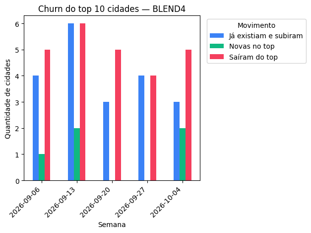

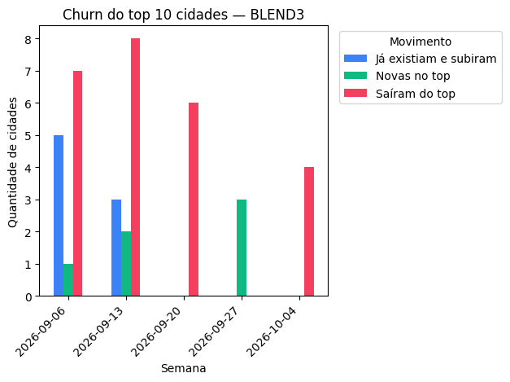